# Predicting Housing Valuations In a Volatile Economy

### 4.1.8 state

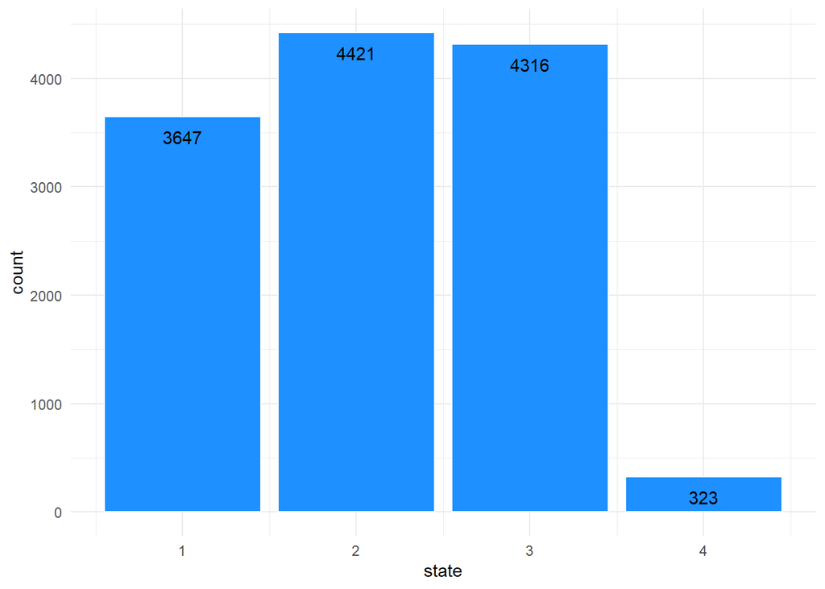

```r
train$state[train$state == 33] <- 3
train %>%
  ggplot( aes(x=state)) +
  geom_bar(fill = "dodgerblue1", color = "white") +
  geom_text(stat='count', aes(label=..count..), vjust=2)+
    theme_minimal()
```

We see a slight increase in the price by state.

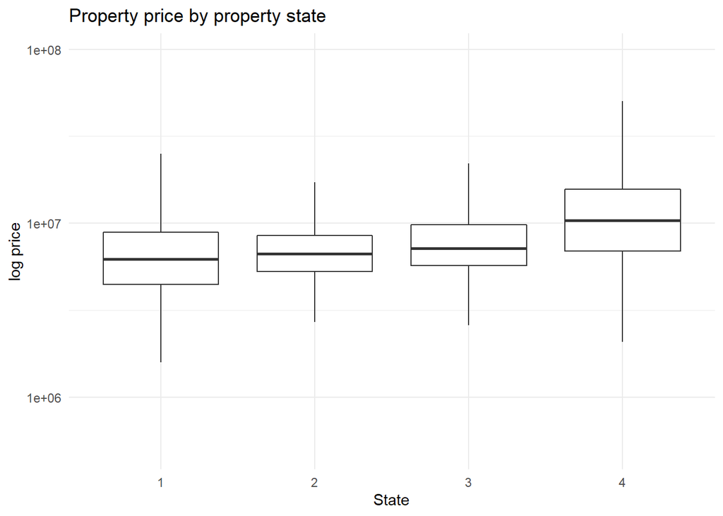

```r
train %>%
  na.omit() %>%
  ggplot(aes(y=price_doc ,x=as.factor(state))) +
  geom_boxplot(outlier.shape = NA) +
  scale_y_log10()+
  labs(x='State', y='log price', title='Property price by property state')+
    theme_minimal()
```

### 4.1.9 product_type

We investigate the property area against owner-occupier purchase or investment. Occupier are buying bigger houses which can be justified by the fact that they are getting both the utility of living in the property and also having it as a investment.

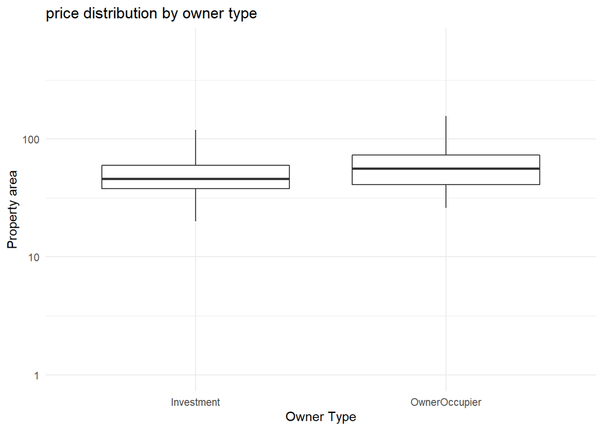

```r
train %>%
  na.omit() %>%
  ggplot(aes(y=full_sq ,x=as.factor(product_type))) +
  geom_boxplot(outlier.shape = NA) +
  scale_y_log10()+
  labs(x='Owner Type', y='Property area', title='price distribution by owner type')+
    theme_minimal()
```

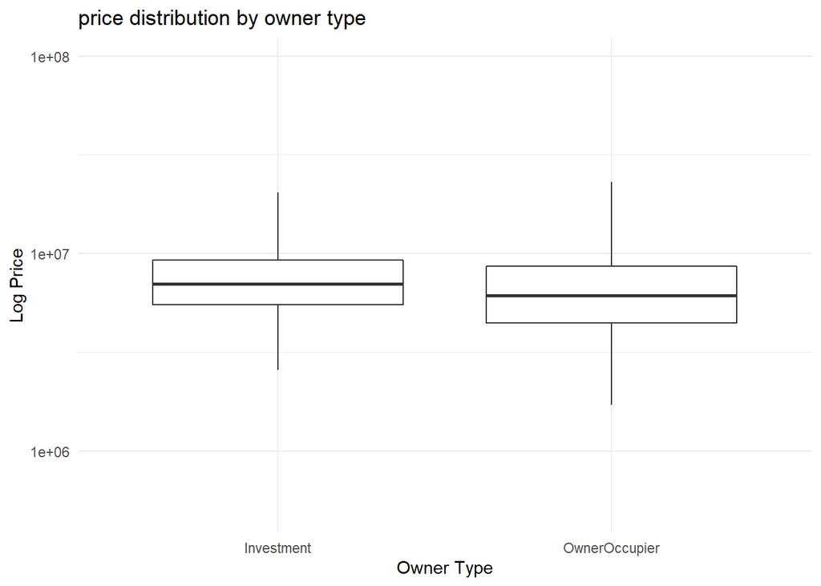

```r
train %>%
  na.omit() %>%
  ggplot(aes(y=price_doc ,x=as.factor(product_type))) +
  geom_boxplot(outlier.shape = NA) +
  scale_y_log10()+
  labs(x='Owner Type', y='Log Price', title='price distribution by owner type')+
    theme_minimal()
```

## 4.2 Macro data

Among the columns of the Macro data, we have picked the most interesting ones.

### 4.2.1 usdrub

The graph is a proxy measurement of the Russia’s economy. Inverting the Rubl to dollar conversion rate will give a better result, as we want to see how the value of Rubl is changing by time.

```r
don <- xts(x = (1/ macro$usdrub), order.by = macro$timestamp)

dygraph(don) %>%
  dyOptions(labelsUTC = TRUE, fillGraph=TRUE, fillAlpha=0.1, drawGrid = TRUE, colors="dodgerblue2") %>%
  dyRangeSelector() %>%
  dyCrosshair(direction = "vertical") %>%
  dyHighlight(highlightCircleSize = 5, highlightSeriesBackgroundAlpha = 0.2, hideOnMouseOut = FALSE)  %>%
  dyRoller(rollPeriod = 1)
```

[interactive chart not shown]

### 4.2.2 unemployment

Unemplyment is another important factor

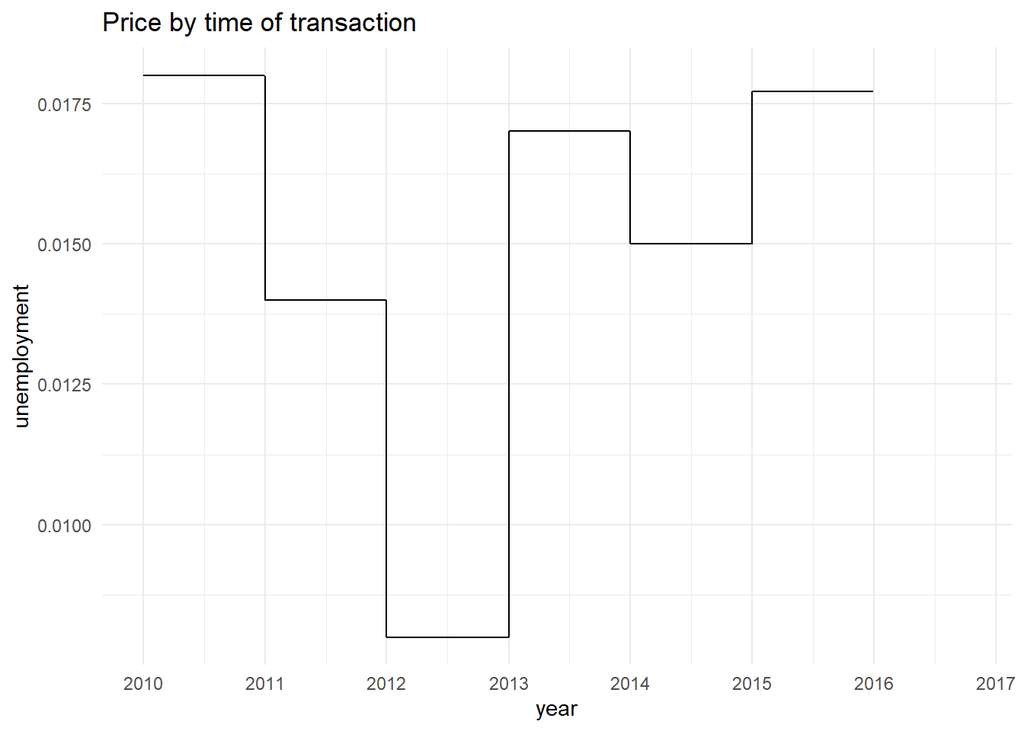

```r
macro %>%
  ggplot(aes(y=unemployment , x= (timestamp) )) +
  geom_line()+
  scale_x_date(date_breaks = "years" , date_labels = "%Y") +
  labs(x='year', y='unemployment', title='Price by time of transaction')+
    theme_minimal()
```

#### 4.2.2.1 unbalanced data and sample selection

Heckman sample selection bias and unbalanced pannel data Now we left-merge the main dataset with the macro data.

now we have to clean the Test data, with the rules used on the train datasets.

```r
test[,"full_sq"][test[,"full_sq"] == 0] <- NA
test[,"life_sq"][test[,"life_sq"]>test[,"full_sq"]] <- NA
test[,"kitch_sq"][test$kitch_sq>test$full_sq] <- NA
test$max_floor[test$max_floor<test$floor] <- NA
test$build_year[test$build_year<1860 |test$build_year> 2018 ] <- NA
test$state[test$state == 33] <- 3
```

# 5 Data type

We transform character vectors to factor.

```r
# First we convert the train dataset characters to factor
train[sapply(train, is.character)] <- lapply(train[sapply(train, is.character)], as.factor)

# now we have to do the same for the Test, however using the factors that has been used in train only
test$product_type  <- factor(test$product_type, levels = levels(train$product_type))
sapply(train,class)
```

```
##    timestamp      full_sq      life_sq        floor    max_floor   build_year
##       "Date"    "integer"    "integer"    "integer"    "integer"    "integer"
##     num_room     kitch_sq        state     material product_type     full_all
##    "integer"    "integer"    "numeric"    "integer"     "factor"    "integer"
##    price_doc       usdrub unemployment
##    "integer"    "numeric"    "numeric"
```

```r
sapply(test,class)
```

```
##    timestamp      full_sq      life_sq        floor    max_floor   build_year
##       "Date"    "integer"    "integer"    "integer"    "integer"    "integer"
##     num_room     kitch_sq        state     material product_type     full_all
##    "integer"    "integer"    "numeric"    "integer"     "factor"    "integer"
##    price_doc       usdrub unemployment
##    "integer"    "numeric"    "numeric"
```

# 6 Imputing the missing data

The followings are several useful links that have been used for this project. This is a book on imputation by the developer of the package mice https://stefvanbuuren.name/fimd/ch-introduction.html The following is a tutorial which explains how to implement the discussed ideas. https://amices.org/Winnipeg/ The following is a series of vignettes that covers the mice packages impelementation. https://www.gerkovink.com/miceVignettes/

Here we check the pattern of missing data, as we can see we have a case of multivariate missing values. In the graph, on the left we have the frequency of each pattern and on the right side the number of missing values.

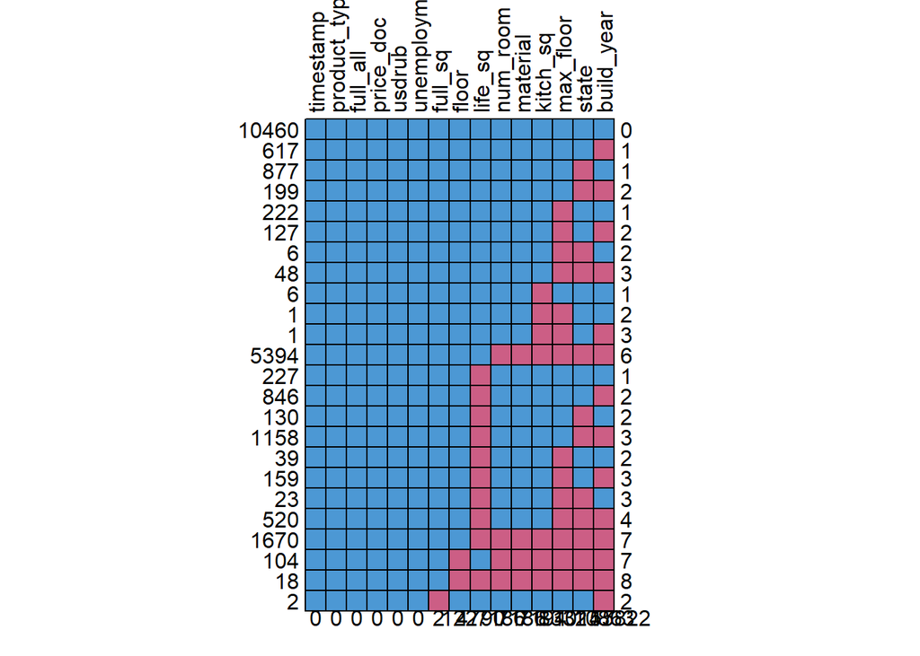

```
##       timestamp product_type full_all price_doc usdrub unemployment full_sq
## 10460         1            1        1         1      1            1       1
## 617           1            1        1         1      1            1       1
## 877           1            1        1         1      1            1       1
## 199           1            1        1         1      1            1       1
## 222           1            1        1         1      1            1       1
## 127           1            1        1         1      1            1       1
## 6             1            1        1         1      1            1       1
## 48            1            1        1         1      1            1       1
## 6             1            1        1         1      1            1       1
## 1             1            1        1         1      1            1       1
## 1             1            1        1         1      1            1       1
## 5394          1            1        1         1      1            1       1
## 227           1            1        1         1      1            1       1
## 846           1            1        1         1      1            1       1
```

[output cut: 37 more lines]

```r
md.pattern(train, rotate.names = TRUE)
```

Now we start the imputing the missing variables using “Multivariate Imputation by Chained Equations”.

First we set the prediction matrix.

```r
pred <- imp$predictorMatrix
```

```r
pred[ ,"timestamp"] <- 0
pred[ ,"full_all"] <- 0
pred[ ,"price_doc"] <- 0
pred
```

```
##              timestamp full_sq life_sq floor max_floor build_year num_room
## timestamp            0       1       1     1         1          1        1
## full_sq              0       0       1     1         1          1        1
## life_sq              0       1       0     1         1          1        1
## floor                0       1       1     0         1          1        1
## max_floor            0       1       1     1         0          1        1
## build_year           0       1       1     1         1          0        1
## num_room             0       1       1     1         1          1        0
## kitch_sq             0       1       1     1         1          1        1
## state                0       1       1     1         1          1        1
## material             0       1       1     1         1          1        1
## product_type         0       1       1     1         1          1        1
## full_all             0       1       1     1         1          1        1
## price_doc            0       1       1     1         1          1        1
## usdrub               0       1       1     1         1          1        1
## unemployment         0       1       1     1         1          1        1
##              kitch_sq state material product_type full_all price_doc usdrub
## timestamp           1     1        1            1        0         0      1
## full_sq             1     1        1            1        0         0      1
## life_sq             1     1        1            1        0         0      1
## floor               1     1        1            1        0         0      1
## max_floor           1     1        1            1        0         0      1
## build_year          1     1        1            1        0         0      1
## num_room            1     1        1            1        0         0      1
## kitch_sq            0     1        1            1        0         0      1
## state               1     0        1            1        0         0      1
## material            1     1        0            1        0         0      1
## product_type        1     1        1            0        0         0      1
## full_all            1     1        1            1        0         0      1
## price_doc           1     1        1            1        0         0      1
## usdrub              1     1        1            1        0         0      0
## unemployment        1     1        1            1        0         0      1
##              unemployment
## timestamp               1
## full_sq                 1
## life_sq                 1
## floor                   1
## max_floor               1
## build_year              1
## num_room                1
## kitch_sq                1
## state                   1
## material                1
## product_type            1
## full_all                1
## price_doc               1
## usdrub                  1
## unemployment            0
```

Now we have to set the statistical method that we want to be used for prediction of each column. The mice package makes the best choices as predictive mean matching, logistic and polynomial based on data and we have to change that for variables that we think it is necessary. The columns that do not have a missing variable do not have a method.

```r
meth <- imp$meth
meth
```

```
##    timestamp      full_sq      life_sq        floor    max_floor   build_year
##           ""        "pmm"        "pmm"        "pmm"        "pmm"        "pmm"
##     num_room     kitch_sq        state     material product_type     full_all
##        "pmm"        "pmm"        "pmm"        "pmm"           ""           ""
##    price_doc       usdrub unemployment
##           ""           ""           ""
```

Now we can run the algorithm

```r
imp <- mice(train, meth = meth, pred = pred, maxit = 5 , seed = 1234 , print = FALSE)
```

We check whether there is a trend in imputation, and the data seems fine.

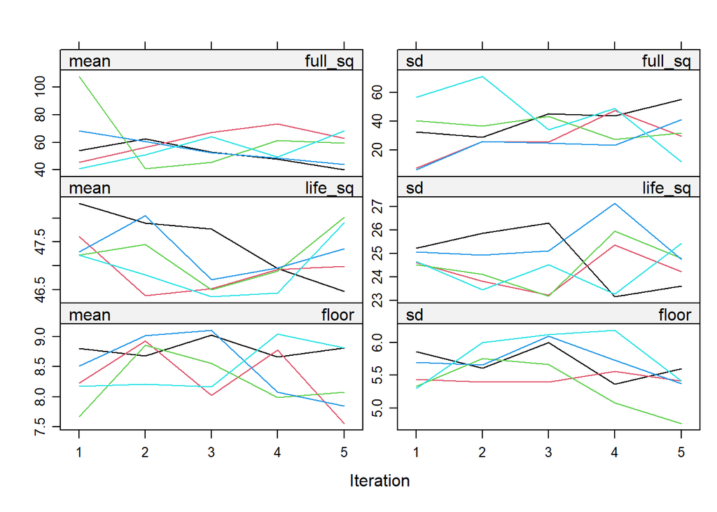

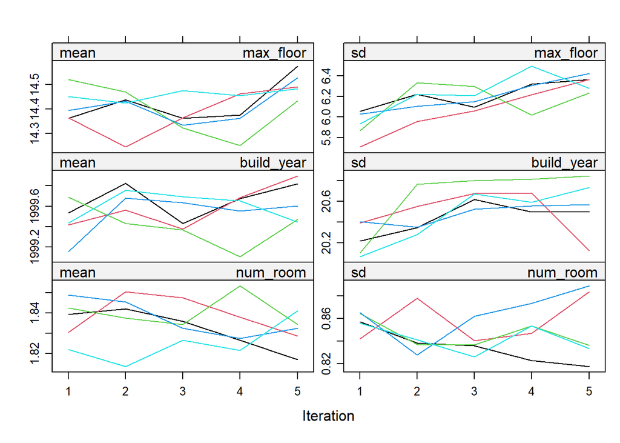

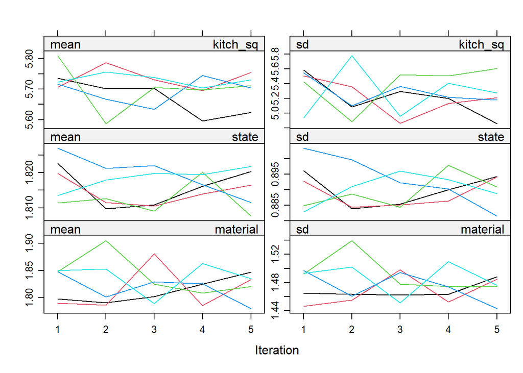

```r
plot(imp)
```

We make a long dataframe, stacking iterations of imputation over each other, since we are using the data for prediction, it is fine to do so.

```r
train_stack <- complete(imp, "long")
dim(train_stack)
```

```
## [1] 114270     17
```

Now we need to impute the test data.

```r
imp1 <- mice(test, maxit=0)
```

```r
pred1 <- imp1$predictorMatrix
```

```r
pred1[ ,"timestamp"] <- 0
pred1[ ,"full_all"] <- 0
pred1[ ,"price_doc"] <- 0
```

```r
meth1 <- imp1$meth
```

```r
imp1 <- mice(test, meth = meth1, pred = pred1, maxit = 5 , seed = 1234 , print = FALSE)
```

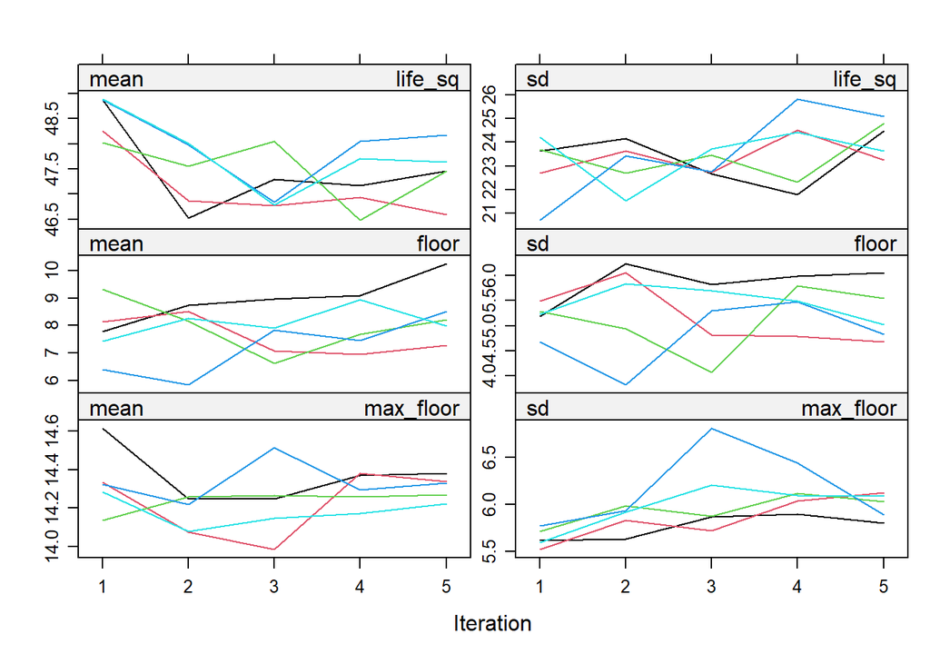

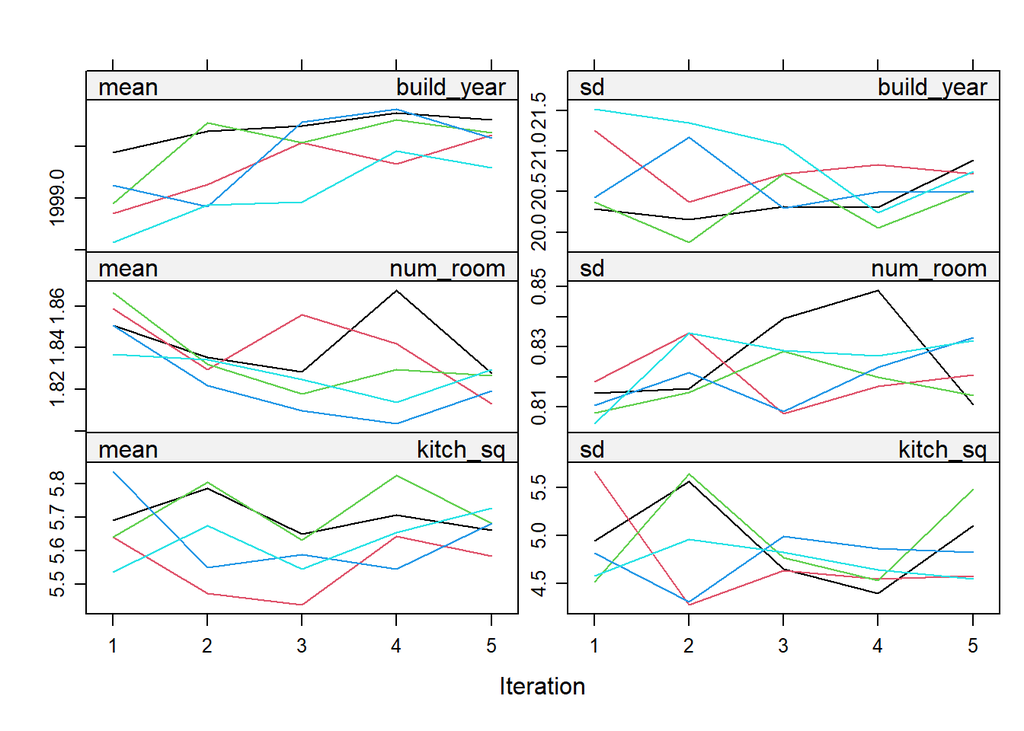

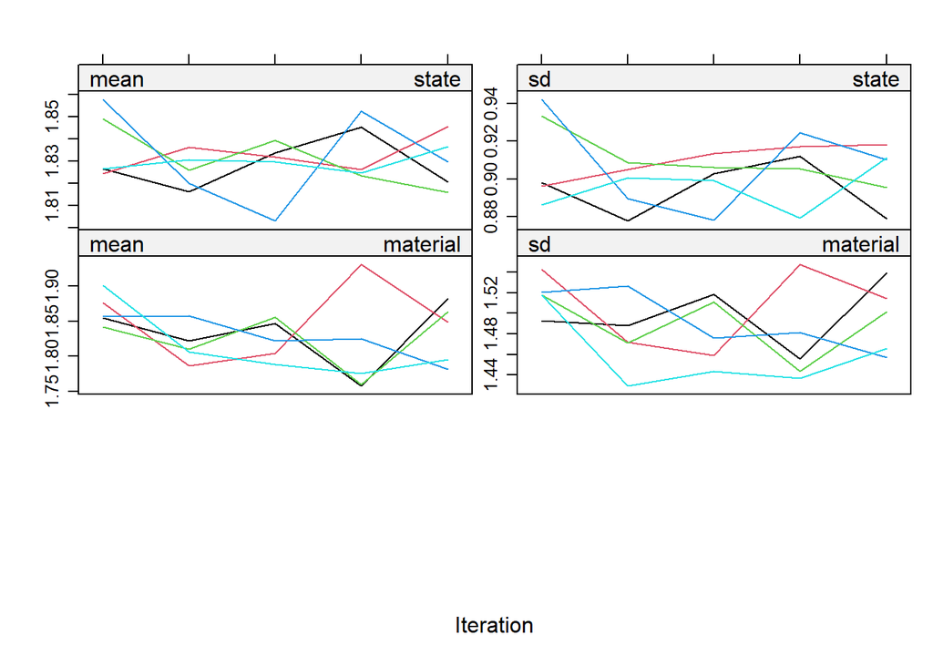

```r
plot(imp1)
```

```r
test_stack <- complete(imp1, "long")
dim(test_stack)
```

```
## [1] 38085    17
```

# 7 Model Fit

For modeling we use XGBoost regressor. It is fast, and has been shown to outperform most competitors.

But first lets do a simple regression.

```r
regression <- lm(price_doc ~ . , data = train_stack)
regression_pred <- predict(regression, newdata = test_stack)
reg_r2 <- sum((regression_pred - test_stack$price_doc)^2)/nrow(test_stack)
reg_r2
```

```
## [1] 1.418832e+13
```

```r
train_df <- data.table(train_stack[,4:17])
test_df  <- data.table(test_stack[,4:17])
train_df$product_type <- as.numeric(train_df$product_type)
test_df$product_type <- as.numeric(test_df$product_type)
```

Setting the validation dataset for XGBoost.

```r
train_id <- sample(1:nrow(train_df), size = floor(0.8 * nrow(train)), replace=FALSE)
# Split in training and validation (80/20)
training <- train_df[train_id,]
validation <- train_df[-train_id,]
```

One hot encoding and setting the target variable

```r
new_tr <- model.matrix(~.+0,data = training[,-c("price_doc"),with=F])
new_val<- model.matrix(~.+0,data = validation[,-c("price_doc"),with=F])
new_ts <- model.matrix(~.+0,data = test_df[,-c("price_doc"),with=F])
train_traget <- training$price_doc
val_traget <- validation$price_doc
test_target <- test_df$price_doc
```

preparing XGBoost matrix.

```r
dtrain <- xgb.DMatrix(data = new_tr,label = train_traget)
dval   <- xgb.DMatrix(data = new_val,label = val_traget)
dtest  <- xgb.DMatrix(data = new_ts,label = test_target)
```

Setting default default parameters for the first run.

```r
params <- list(booster = "gbtree", objective = "reg:squarederror",
               eta=0.3, gamma=0, max_depth=6, min_child_weight=1,
               subsample=1, colsample_bytree=1)
```

Running the first run

```r
set.seed(1234)
xgb_base <- xgb.train (params = params,
                       data = dtrain,
                       nrounds =1000,
                       print_every_n = 200,
                       eval_metric = 'rmse',
                       early_stopping_rounds = 50,
                       watchlist = list(train= dtrain, val= dval))
```

Now we run a random parameter search with 1000 iteration

```r
# strt time
start.time <- Sys.time()

# empty lists
lowest_error_list = list()
parameters_list = list()

# 1000 rows with random hyperparameters
set.seed(1234)
for (iter in 1:1000){
  param <- list(booster = "gbtree",
                objective = "reg:squarederror",
                max_depth = sample(3:10, 1),
                eta = runif(1, .01, .3),
                subsample = runif(1, .7, 1),
                colsample_bytree = runif(1, .6, 1),
                min_child_weight = sample(0:10, 1)
  )
  parameters <- as.data.frame(param)
  parameters_list[[iter]] <- parameters
}

# object that contains all randomly created hyperparameters
parameters_df = do.call(rbind, parameters_list)

# using randomly created parameters to create 1000 XGBoost-models
for (row in 1:nrow(parameters_df)){
  set.seed(20)
  mdcv <- xgb.train(data=dtrain,
                    booster = "gbtree",
                    objective = "reg:squarederror",
                    max_depth = parameters_df$max_depth[row],
                    eta = parameters_df$eta[row],
                    subsample = parameters_df$subsample[row],
                    colsample_bytree = parameters_df$colsample_bytree[row],
                    min_child_weight = parameters_df$min_child_weight[row],
                    nrounds= 300,
                    eval_metric = "rmse",
                    early_stopping_rounds= 30,
                    watchlist = list(train= dtrain, val= dval)
  )
  lowest_error <- as.data.frame(1 - min(mdcv$evaluation_log$val_error))
  lowest_error_list[[ row]] <- lowest_error
}

# object that contains all accuracy's
lowest_error_df = do.call(rbind, lowest_error_list)

# binding columns of accuracy values and random hyperparameter values
randomsearch = cbind(lowest_error_df, parameters_df)

# end time
end.time <- Sys.time()
time.taken <- end.time - start.time
time.taken
```

```r
time.taken
```

```
## Time difference of 1.790259 hours
```

Here we have a table of our random search results

```r
randomsearch <- as.data.frame(randomsearch) %>%
  rename(val_acc = `1 - min(mdcv$evaluation_log$val_error)`) %>%
  arrange(-val_acc)
```

We calculate the error of the best model on the validation set.

```r
# Tuned-XGBoost model
set.seed(1234)
params <- list(booster = "gbtree",
               objective = "reg:squarederror",
               max_depth = randomsearch[1,]$max_depth,
               eta = randomsearch[1,]$eta,
               subsample = randomsearch[1,]$subsample,
               colsample_bytree = randomsearch[1,]$colsample_bytree,
               min_child_weight = randomsearch[1,]$min_child_weight)
xgb_tuned <- xgb.train(params = params,
                       data = dtrain,
                       nrounds =1000,
                       print_every_n = 100,
                       eval_metric = "rmse",
                       early_stopping_rounds = 30,
                       watchlist = list(train= dtrain, val= dval))

# Make prediction on dvalid
validation$pred_survived_tuned <- predict(xgb_tuned, dval)

val_r2 = sum((validation$price_doc - validation$pred_survived_tuned) ^ 2 ) / nrow(validation)
val_r2
```

```r
val_r2
```

```
## [1] 5.080351e+12
```

And finally here we have error on the test set.

```r
set.seed(1234)
params <- list(booster = "gbtree",
               objective = "reg:squarederror",
               max_depth = randomsearch[1,]$max_depth,
               eta = randomsearch[1,]$eta,
               subsample = randomsearch[1,]$subsample,
               colsample_bytree = randomsearch[1,]$colsample_bytree,
               min_child_weight = randomsearch[1,]$min_child_weight)
xgb_tuned <- xgb.train(params = params,
                       data = dtrain,
                       nrounds =1000,
                       eval_metric = "rmse",
                       early_stopping_rounds = 30,
                       watchlist = list(train= dtrain, val= dtest))
# Make prediction on dvalid
test_df$pred_price_tuned <- predict(xgb_tuned, dtest)

test_r2 = sum((test_df$price_doc - test_df$pred_price_tuned) ^ 2 ) / nrow(test_df)
test_r2
```

```r
test_r2
```

```
## [1] 7.966814e+12
```

As one would expect, a randomly tuned XGBoost, drastically outperforms simple regression

```r
round(test_r2/reg_r2,2)
```

```
## [1] 0.56
```